# Praktikum 4

Latihan

Nabila Nur Faizah (M0401241048)

18 September 2026

# White Noise

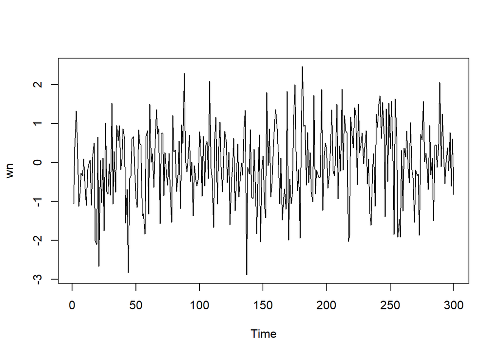

```r
set.seed(1048)
wn <- rnorm(300)
ts.plot(wn)
```

# Proses MA (2)

## Pembangkitan Model

### Manual

```r
ma <- wn[1]
ma[2] <- wn[2] + 0.4 * wn[1]

for(i in 3:300){
   ma[i] <- wn[i] + 0.4 * wn[i - 1] + 0.6 * wn[i - 2]
}
ma
```

```
##   [1] -1.05904811 -0.02239608  0.84487319  1.26935901 -0.13233979 -0.94650040
##   [7] -1.27302282 -0.93257038 -0.20948698 -0.84375297 -1.31986306 -1.03172899
##  [13] -0.77220254 -0.06164654 -1.09349057 -0.26429649 -0.09777742 -1.72804606
##  [19] -2.60376052 -1.39132346 -3.66664759 -0.61960280 -2.61273370 -0.26645449
##  [25] -2.32703949  0.38658598 -1.39004774 -0.49767521 -0.80366432 -1.34193156
##  [31]  1.16489039 -0.96783248  0.76369215 -1.29136639  0.81456487  0.48236602
##  [37]  1.74372597  0.53083383  0.56713354  0.78510851  0.99243764 -0.78850278
##  [43] -0.94376719 -4.03032049 -1.95219410 -2.20412161  0.22077134  0.69496167
##  [49]  0.52951702 -0.57554525 -1.58292862 -0.17992596  0.13559175  1.15519072
##  [55] -0.89162673 -1.59054022 -3.18805627 -0.84797971 -0.01836624 -0.58586163
##  [61]  1.45007397 -0.19047103  1.12671518 -0.54419029  0.24144397  1.11449173
##  [67]  1.48855336  1.97024328 -0.78458242  0.63827211  0.10884769 -0.10113063
##  [73]  0.36160259 -0.72291173 -0.55483175 -0.18132028 -1.01880324 -1.69429360
##  [79]  0.13842276 -0.16186610  1.15849591 -0.44877536 -0.42478165 -0.02484026
##  [85] -1.15445539  0.82793828  0.16930391  3.07296855  1.28319888  1.16989388
```

[output cut: 35 more lines]

### Fungsi arima.sim

```r
set.seed(1048)
ma2 <- arima.sim(list(order=c(0,0,2), ma=c(0.4, 0.6)), n=300)
ma2
```

```
## Time Series:
## Start = 1
## End = 300
## Frequency = 1
##   [1]  0.84487319  1.26935901 -0.13233979 -0.94650040 -1.27302282 -0.93257038
##   [7] -0.20948698 -0.84375297 -1.31986306 -1.03172899 -0.77220254 -0.06164654
##  [13] -1.09349057 -0.26429649 -0.09777742 -1.72804606 -2.60376052 -1.39132346
##  [19] -3.66664759 -0.61960280 -2.61273370 -0.26645449 -2.32703949  0.38658598
##  [25] -1.39004774 -0.49767521 -0.80366432 -1.34193156  1.16489039 -0.96783248
##  [31]  0.76369215 -1.29136639  0.81456487  0.48236602  1.74372597  0.53083383
##  [37]  0.56713354  0.78510851  0.99243764 -0.78850278 -0.94376719 -4.03032049
##  [43] -1.95219410 -2.20412161  0.22077134  0.69496167  0.52951702 -0.57554525
##  [49] -1.58292862 -0.17992596  0.13559175  1.15519072 -0.89162673 -1.59054022
##  [55] -3.18805627 -0.84797971 -0.01836624 -0.58586163  1.45007397 -0.19047103
##  [61]  1.12671518 -0.54419029  0.24144397  1.11449173  1.48855336  1.97024328
```

[output cut: 39 more lines]

## Karakteristik MA(2)

### Plot Time Series

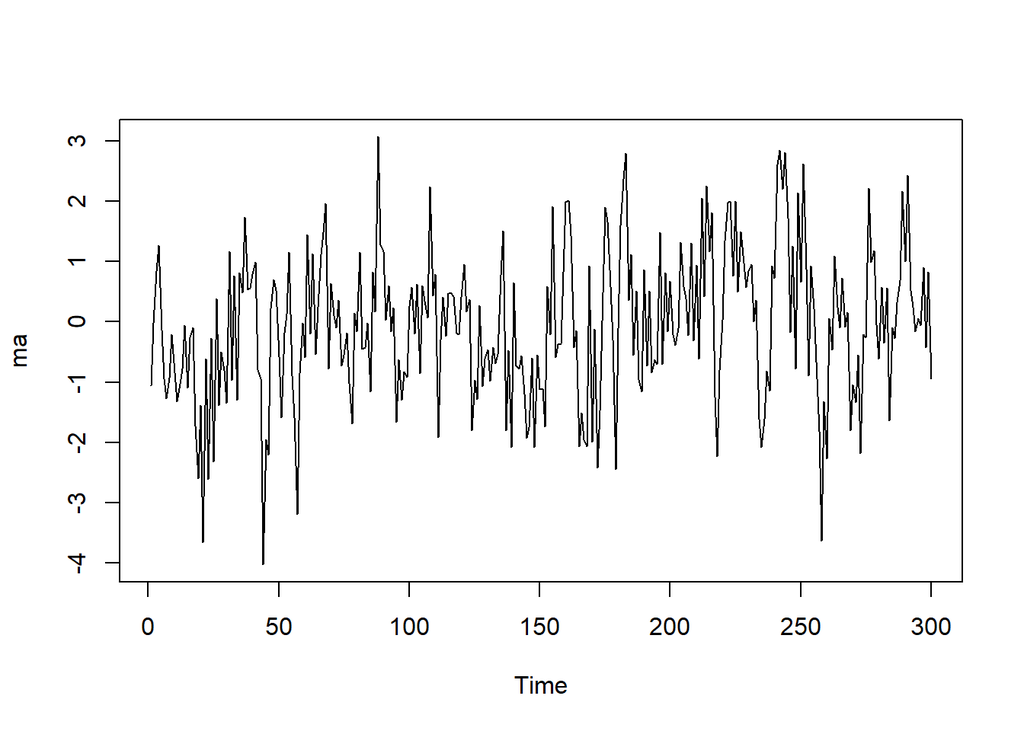

```r
ts.plot(ma)
```

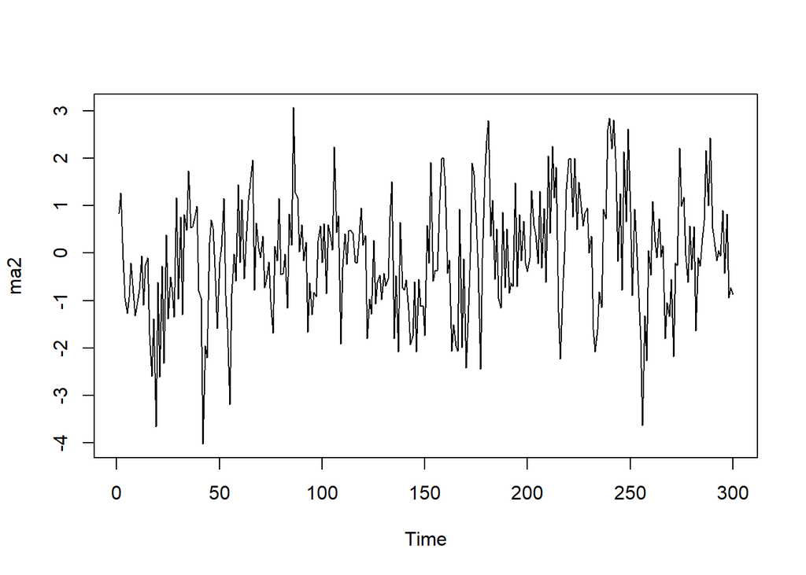

```r
ts.plot(ma2)
```

### Plot ACF

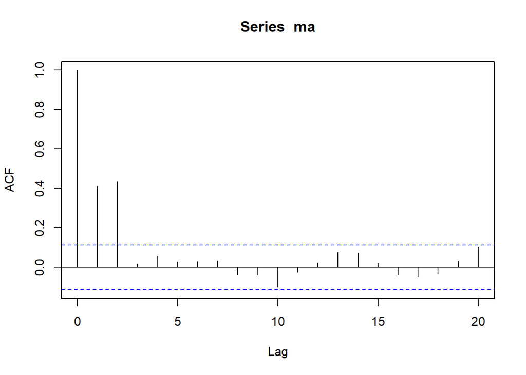

```r
acf(ma,lag.max = 20)
```

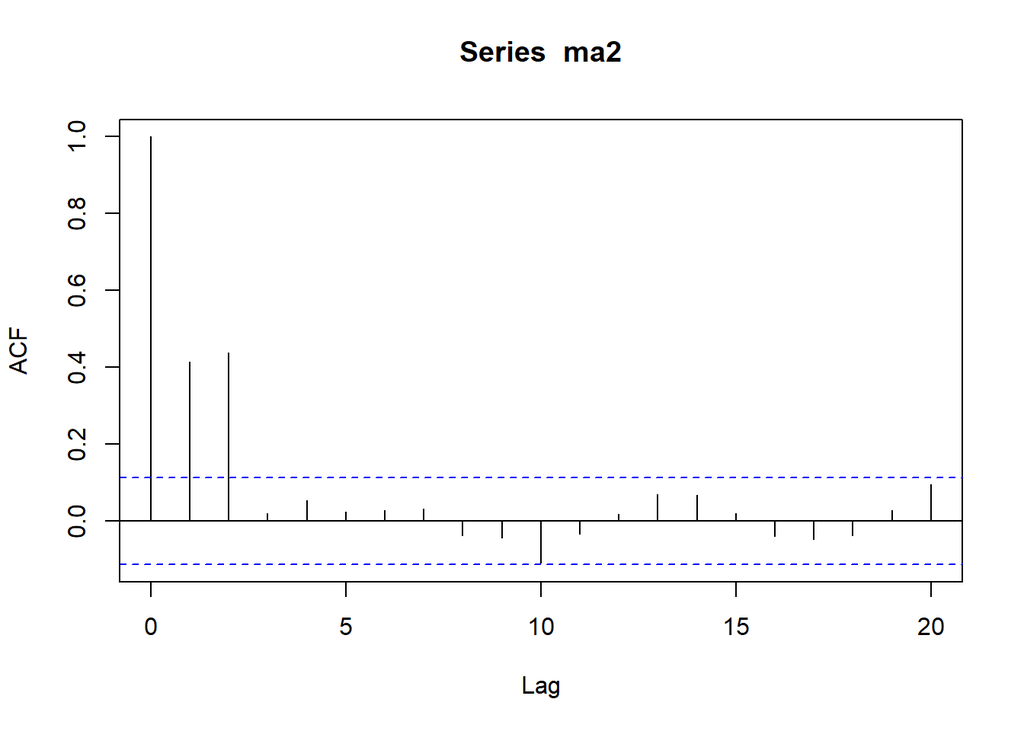

```r
acf(ma2,lag.max = 20)
```

### Plot PACF

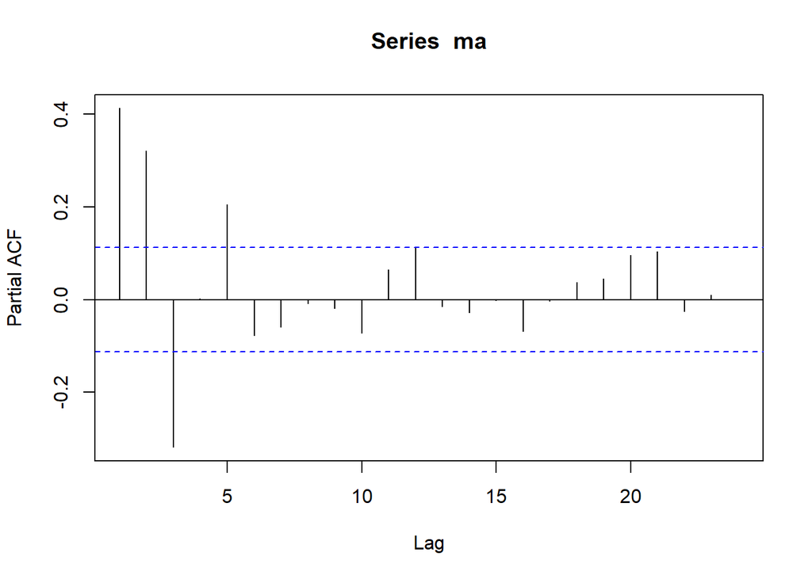

```r
pacf(ma)
```

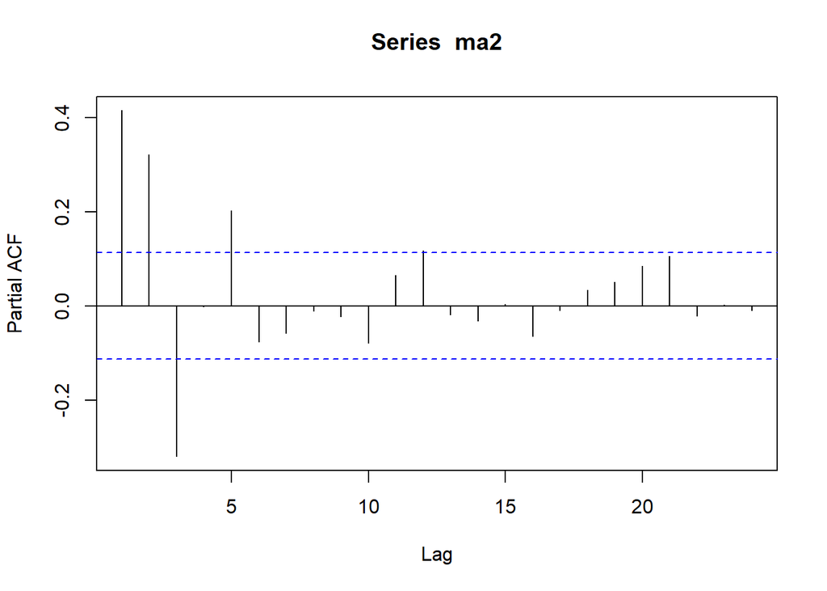

```r
pacf(ma2)
```

### Plot EACF

```r
TSA::eacf(ma)
```

```
## AR/MA
##   0 1 2 3 4 5 6 7 8 9 10 11 12 13
## 0 x x o o o o o o o o o  o  o  o
## 1 x x x o o o o o o o o  o  o  o
## 2 x x x x o o o o o o o  o  o  o
## 3 o x x o o o o o o o o  o  o  o
## 4 o x x o o x o o o o o  o  o  o
## 5 x x x x x o o o o o o  o  o  o
## 6 x x o o x o o x o o o  o  o  o
## 7 x x o o x o o x o o o  o  o  o
```

```r
TSA::eacf(ma2)
```

```
## AR/MA
##   0 1 2 3 4 5 6 7 8 9 10 11 12 13
## 0 x x o o o o o o o o o  o  o  o
## 1 x x x o o o o o o o o  o  o  o
## 2 x x x x o o o o o o o  o  o  o
## 3 o x x o o o o o o o o  o  o  o
## 4 o x x o o x o o o o o  o  o  o
## 5 x x x x x o o o o o o  o  o  o
## 6 x x o o x o o x o o o  o  o  o
## 7 x x o o x o o x o o o  o  o  o
```

### Identifikasi Stasioneritas

Berdasarkan plot time series yang telah dibuat, model ma atau moving average yang dibangkitkan secara manual tampak stasioner dalam rata-rata. Walaupun ada titik yang menyebar lebar, titik-titik tersebut merupakan fluktuasi acak dan tidak mengubah struktur varians. Secara keseluruhan, plot menunjukkan bahwa model ini stasioner dalam ragam. Begitu juga dengan model ma2 atau moving average yang dibangkitkan dengan fungsi arima.sim. Model ini tampak stasioner dalam rata-rata dan ragam dengan kasus yang sama pada stasioneritas ragamnya.

## Scatter Plot antar Lag

### $Y_{t}$ dengan $Y_{t-1}$

```r
yt_ma <- ma[-1]
yt_ma
```

```
##   [1] -0.02239608  0.84487319  1.26935901 -0.13233979 -0.94650040 -1.27302282
##   [7] -0.93257038 -0.20948698 -0.84375297 -1.31986306 -1.03172899 -0.77220254
##  [13] -0.06164654 -1.09349057 -0.26429649 -0.09777742 -1.72804606 -2.60376052
##  [19] -1.39132346 -3.66664759 -0.61960280 -2.61273370 -0.26645449 -2.32703949
##  [25]  0.38658598 -1.39004774 -0.49767521 -0.80366432 -1.34193156  1.16489039
##  [31] -0.96783248  0.76369215 -1.29136639  0.81456487  0.48236602  1.74372597
##  [37]  0.53083383  0.56713354  0.78510851  0.99243764 -0.78850278 -0.94376719
##  [43] -4.03032049 -1.95219410 -2.20412161  0.22077134  0.69496167  0.52951702
##  [49] -0.57554525 -1.58292862 -0.17992596  0.13559175  1.15519072 -0.89162673
##  [55] -1.59054022 -3.18805627 -0.84797971 -0.01836624 -0.58586163  1.45007397
##  [61] -0.19047103  1.12671518 -0.54419029  0.24144397  1.11449173  1.48855336
##  [67]  1.97024328 -0.78458242  0.63827211  0.10884769 -0.10113063  0.36160259
##  [73] -0.72291173 -0.55483175 -0.18132028 -1.01880324 -1.69429360  0.13842276
##  [79] -0.16186610  1.15849591 -0.44877536 -0.42478165 -0.02484026 -1.15445539
##  [85]  0.82793828  0.16930391  3.07296855  1.28319888  1.16989388  0.03098812
```

[output cut: 35 more lines]

```r
yt_1_ma <- ma[-300]
yt_1_ma
```

```
##   [1] -1.05904811 -0.02239608  0.84487319  1.26935901 -0.13233979 -0.94650040
##   [7] -1.27302282 -0.93257038 -0.20948698 -0.84375297 -1.31986306 -1.03172899
##  [13] -0.77220254 -0.06164654 -1.09349057 -0.26429649 -0.09777742 -1.72804606
##  [19] -2.60376052 -1.39132346 -3.66664759 -0.61960280 -2.61273370 -0.26645449
##  [25] -2.32703949  0.38658598 -1.39004774 -0.49767521 -0.80366432 -1.34193156
##  [31]  1.16489039 -0.96783248  0.76369215 -1.29136639  0.81456487  0.48236602
##  [37]  1.74372597  0.53083383  0.56713354  0.78510851  0.99243764 -0.78850278
##  [43] -0.94376719 -4.03032049 -1.95219410 -2.20412161  0.22077134  0.69496167
##  [49]  0.52951702 -0.57554525 -1.58292862 -0.17992596  0.13559175  1.15519072
##  [55] -0.89162673 -1.59054022 -3.18805627 -0.84797971 -0.01836624 -0.58586163
##  [61]  1.45007397 -0.19047103  1.12671518 -0.54419029  0.24144397  1.11449173
##  [67]  1.48855336  1.97024328 -0.78458242  0.63827211  0.10884769 -0.10113063
##  [73]  0.36160259 -0.72291173 -0.55483175 -0.18132028 -1.01880324 -1.69429360
##  [79]  0.13842276 -0.16186610  1.15849591 -0.44877536 -0.42478165 -0.02484026
##  [85] -1.15445539  0.82793828  0.16930391  3.07296855  1.28319888  1.16989388
```

[output cut: 35 more lines]

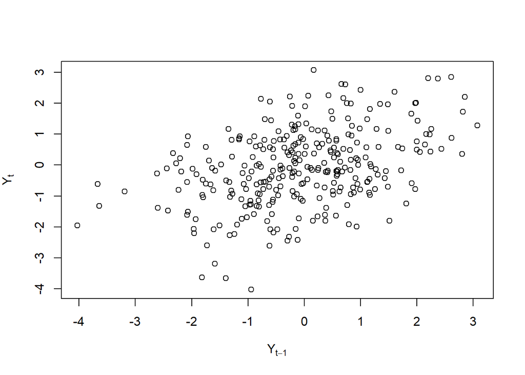

```r
plot(y=yt_ma,x=yt_1_ma, xlab = expression(Y[t-1]), ylab = expression(Y[t]))
```

```r
cor(yt_ma,yt_1_ma)
```

```
## [1] 0.4135016
```

```r
yt_ma2 <- ma2[-1]
yt_ma2
```

```
##   [1]  1.26935901 -0.13233979 -0.94650040 -1.27302282 -0.93257038 -0.20948698
##   [7] -0.84375297 -1.31986306 -1.03172899 -0.77220254 -0.06164654 -1.09349057
##  [13] -0.26429649 -0.09777742 -1.72804606 -2.60376052 -1.39132346 -3.66664759
##  [19] -0.61960280 -2.61273370 -0.26645449 -2.32703949  0.38658598 -1.39004774
##  [25] -0.49767521 -0.80366432 -1.34193156  1.16489039 -0.96783248  0.76369215
##  [31] -1.29136639  0.81456487  0.48236602  1.74372597  0.53083383  0.56713354
##  [37]  0.78510851  0.99243764 -0.78850278 -0.94376719 -4.03032049 -1.95219410
##  [43] -2.20412161  0.22077134  0.69496167  0.52951702 -0.57554525 -1.58292862
##  [49] -0.17992596  0.13559175  1.15519072 -0.89162673 -1.59054022 -3.18805627
##  [55] -0.84797971 -0.01836624 -0.58586163  1.45007397 -0.19047103  1.12671518
##  [61] -0.54419029  0.24144397  1.11449173  1.48855336  1.97024328 -0.78458242
##  [67]  0.63827211  0.10884769 -0.10113063  0.36160259 -0.72291173 -0.55483175
##  [73] -0.18132028 -1.01880324 -1.69429360  0.13842276 -0.16186610  1.15849591
##  [79] -0.44877536 -0.42478165 -0.02484026 -1.15445539  0.82793828  0.16930391
##  [85]  3.07296855  1.28319888  1.16989388  0.03098812  0.59488650 -0.15762106
```

[output cut: 35 more lines]

```r
yt_1_ma2 <- ma2[-300]
yt_1_ma2
```

```
##   [1]  0.84487319  1.26935901 -0.13233979 -0.94650040 -1.27302282 -0.93257038
##   [7] -0.20948698 -0.84375297 -1.31986306 -1.03172899 -0.77220254 -0.06164654
##  [13] -1.09349057 -0.26429649 -0.09777742 -1.72804606 -2.60376052 -1.39132346
##  [19] -3.66664759 -0.61960280 -2.61273370 -0.26645449 -2.32703949  0.38658598
##  [25] -1.39004774 -0.49767521 -0.80366432 -1.34193156  1.16489039 -0.96783248
##  [31]  0.76369215 -1.29136639  0.81456487  0.48236602  1.74372597  0.53083383
##  [37]  0.56713354  0.78510851  0.99243764 -0.78850278 -0.94376719 -4.03032049
##  [43] -1.95219410 -2.20412161  0.22077134  0.69496167  0.52951702 -0.57554525
##  [49] -1.58292862 -0.17992596  0.13559175  1.15519072 -0.89162673 -1.59054022
##  [55] -3.18805627 -0.84797971 -0.01836624 -0.58586163  1.45007397 -0.19047103
##  [61]  1.12671518 -0.54419029  0.24144397  1.11449173  1.48855336  1.97024328
##  [67] -0.78458242  0.63827211  0.10884769 -0.10113063  0.36160259 -0.72291173
##  [73] -0.55483175 -0.18132028 -1.01880324 -1.69429360  0.13842276 -0.16186610
##  [79]  1.15849591 -0.44877536 -0.42478165 -0.02484026 -1.15445539  0.82793828
##  [85]  0.16930391  3.07296855  1.28319888  1.16989388  0.03098812  0.59488650
```

[output cut: 35 more lines]

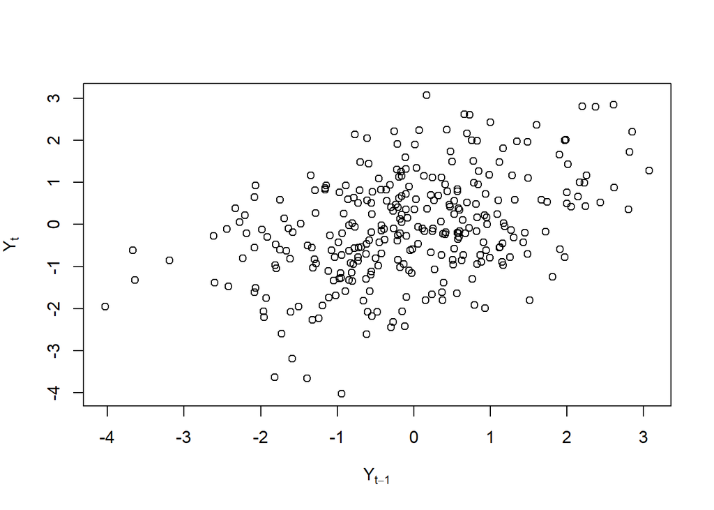

```r
plot(y=yt_ma2,x=yt_1_ma2, xlab = expression(Y[t-1]), ylab = expression(Y[t]))
```

```r
cor(yt_ma2,yt_1_ma2)
```

```
## [1] 0.4156983
```

### $Y_{t}$ dengan $Y_{t-2}$

```r
yt_ma <- ma[-c(1,2)]
yt_ma
```

```
##   [1]  0.84487319  1.26935901 -0.13233979 -0.94650040 -1.27302282 -0.93257038
##   [7] -0.20948698 -0.84375297 -1.31986306 -1.03172899 -0.77220254 -0.06164654
##  [13] -1.09349057 -0.26429649 -0.09777742 -1.72804606 -2.60376052 -1.39132346
##  [19] -3.66664759 -0.61960280 -2.61273370 -0.26645449 -2.32703949  0.38658598
##  [25] -1.39004774 -0.49767521 -0.80366432 -1.34193156  1.16489039 -0.96783248
##  [31]  0.76369215 -1.29136639  0.81456487  0.48236602  1.74372597  0.53083383
##  [37]  0.56713354  0.78510851  0.99243764 -0.78850278 -0.94376719 -4.03032049
##  [43] -1.95219410 -2.20412161  0.22077134  0.69496167  0.52951702 -0.57554525
##  [49] -1.58292862 -0.17992596  0.13559175  1.15519072 -0.89162673 -1.59054022
##  [55] -3.18805627 -0.84797971 -0.01836624 -0.58586163  1.45007397 -0.19047103
##  [61]  1.12671518 -0.54419029  0.24144397  1.11449173  1.48855336  1.97024328
##  [67] -0.78458242  0.63827211  0.10884769 -0.10113063  0.36160259 -0.72291173
##  [73] -0.55483175 -0.18132028 -1.01880324 -1.69429360  0.13842276 -0.16186610
##  [79]  1.15849591 -0.44877536 -0.42478165 -0.02484026 -1.15445539  0.82793828
##  [85]  0.16930391  3.07296855  1.28319888  1.16989388  0.03098812  0.59488650
```

[output cut: 35 more lines]

```r
yt_2_ma <- ma[-c(299,300)]
yt_2_ma
```

```
##   [1] -1.05904811 -0.02239608  0.84487319  1.26935901 -0.13233979 -0.94650040
##   [7] -1.27302282 -0.93257038 -0.20948698 -0.84375297 -1.31986306 -1.03172899
##  [13] -0.77220254 -0.06164654 -1.09349057 -0.26429649 -0.09777742 -1.72804606
##  [19] -2.60376052 -1.39132346 -3.66664759 -0.61960280 -2.61273370 -0.26645449
##  [25] -2.32703949  0.38658598 -1.39004774 -0.49767521 -0.80366432 -1.34193156
##  [31]  1.16489039 -0.96783248  0.76369215 -1.29136639  0.81456487  0.48236602
##  [37]  1.74372597  0.53083383  0.56713354  0.78510851  0.99243764 -0.78850278
##  [43] -0.94376719 -4.03032049 -1.95219410 -2.20412161  0.22077134  0.69496167
##  [49]  0.52951702 -0.57554525 -1.58292862 -0.17992596  0.13559175  1.15519072
##  [55] -0.89162673 -1.59054022 -3.18805627 -0.84797971 -0.01836624 -0.58586163
##  [61]  1.45007397 -0.19047103  1.12671518 -0.54419029  0.24144397  1.11449173
##  [67]  1.48855336  1.97024328 -0.78458242  0.63827211  0.10884769 -0.10113063
##  [73]  0.36160259 -0.72291173 -0.55483175 -0.18132028 -1.01880324 -1.69429360
##  [79]  0.13842276 -0.16186610  1.15849591 -0.44877536 -0.42478165 -0.02484026
##  [85] -1.15445539  0.82793828  0.16930391  3.07296855  1.28319888  1.16989388
```

[output cut: 35 more lines]

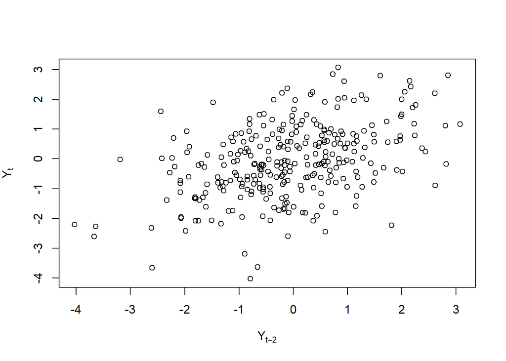

```r
plot(y=yt_ma,x=yt_2_ma, xlab = expression(Y[t-2]), ylab = expression(Y[t]))
```

```r
cor(yt_ma,yt_2_ma)
```

```
## [1] 0.4375855
```

```r
yt_ma2 <- ma2[-c(1,2)]
yt_ma2
```

```
##   [1] -0.13233979 -0.94650040 -1.27302282 -0.93257038 -0.20948698 -0.84375297
##   [7] -1.31986306 -1.03172899 -0.77220254 -0.06164654 -1.09349057 -0.26429649
##  [13] -0.09777742 -1.72804606 -2.60376052 -1.39132346 -3.66664759 -0.61960280
##  [19] -2.61273370 -0.26645449 -2.32703949  0.38658598 -1.39004774 -0.49767521
##  [25] -0.80366432 -1.34193156  1.16489039 -0.96783248  0.76369215 -1.29136639
##  [31]  0.81456487  0.48236602  1.74372597  0.53083383  0.56713354  0.78510851
##  [37]  0.99243764 -0.78850278 -0.94376719 -4.03032049 -1.95219410 -2.20412161
##  [43]  0.22077134  0.69496167  0.52951702 -0.57554525 -1.58292862 -0.17992596
##  [49]  0.13559175  1.15519072 -0.89162673 -1.59054022 -3.18805627 -0.84797971
##  [55] -0.01836624 -0.58586163  1.45007397 -0.19047103  1.12671518 -0.54419029
##  [61]  0.24144397  1.11449173  1.48855336  1.97024328 -0.78458242  0.63827211
##  [67]  0.10884769 -0.10113063  0.36160259 -0.72291173 -0.55483175 -0.18132028
##  [73] -1.01880324 -1.69429360  0.13842276 -0.16186610  1.15849591 -0.44877536
##  [79] -0.42478165 -0.02484026 -1.15445539  0.82793828  0.16930391  3.07296855
##  [85]  1.28319888  1.16989388  0.03098812  0.59488650 -0.15762106  0.23751592
```

[output cut: 35 more lines]

```r
yt_2_ma2 <- ma2[-c(299,300)]
yt_2_ma2
```

```
##   [1]  0.84487319  1.26935901 -0.13233979 -0.94650040 -1.27302282 -0.93257038
##   [7] -0.20948698 -0.84375297 -1.31986306 -1.03172899 -0.77220254 -0.06164654
##  [13] -1.09349057 -0.26429649 -0.09777742 -1.72804606 -2.60376052 -1.39132346
##  [19] -3.66664759 -0.61960280 -2.61273370 -0.26645449 -2.32703949  0.38658598
##  [25] -1.39004774 -0.49767521 -0.80366432 -1.34193156  1.16489039 -0.96783248
##  [31]  0.76369215 -1.29136639  0.81456487  0.48236602  1.74372597  0.53083383
##  [37]  0.56713354  0.78510851  0.99243764 -0.78850278 -0.94376719 -4.03032049
##  [43] -1.95219410 -2.20412161  0.22077134  0.69496167  0.52951702 -0.57554525
##  [49] -1.58292862 -0.17992596  0.13559175  1.15519072 -0.89162673 -1.59054022
##  [55] -3.18805627 -0.84797971 -0.01836624 -0.58586163  1.45007397 -0.19047103
##  [61]  1.12671518 -0.54419029  0.24144397  1.11449173  1.48855336  1.97024328
##  [67] -0.78458242  0.63827211  0.10884769 -0.10113063  0.36160259 -0.72291173
##  [73] -0.55483175 -0.18132028 -1.01880324 -1.69429360  0.13842276 -0.16186610
##  [79]  1.15849591 -0.44877536 -0.42478165 -0.02484026 -1.15445539  0.82793828
##  [85]  0.16930391  3.07296855  1.28319888  1.16989388  0.03098812  0.59488650
```

[output cut: 35 more lines]

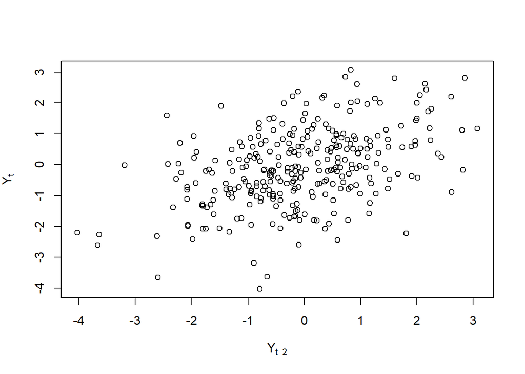

```r
plot(y=yt_ma2,x=yt_2_ma2, xlab = expression(Y[t-2]), ylab = expression(Y[t]))
```

```r
cor(yt_ma2,yt_2_ma2)
```

```
## [1] 0.4401526
```

### $Y_{t}$ dengan $Y_{t-3}$

```r
yt_ma <- ma[-c(1,2,3)]
yt_ma
```

```
##   [1]  1.26935901 -0.13233979 -0.94650040 -1.27302282 -0.93257038 -0.20948698
##   [7] -0.84375297 -1.31986306 -1.03172899 -0.77220254 -0.06164654 -1.09349057
##  [13] -0.26429649 -0.09777742 -1.72804606 -2.60376052 -1.39132346 -3.66664759
##  [19] -0.61960280 -2.61273370 -0.26645449 -2.32703949  0.38658598 -1.39004774
##  [25] -0.49767521 -0.80366432 -1.34193156  1.16489039 -0.96783248  0.76369215
##  [31] -1.29136639  0.81456487  0.48236602  1.74372597  0.53083383  0.56713354
##  [37]  0.78510851  0.99243764 -0.78850278 -0.94376719 -4.03032049 -1.95219410
##  [43] -2.20412161  0.22077134  0.69496167  0.52951702 -0.57554525 -1.58292862
##  [49] -0.17992596  0.13559175  1.15519072 -0.89162673 -1.59054022 -3.18805627
##  [55] -0.84797971 -0.01836624 -0.58586163  1.45007397 -0.19047103  1.12671518
##  [61] -0.54419029  0.24144397  1.11449173  1.48855336  1.97024328 -0.78458242
##  [67]  0.63827211  0.10884769 -0.10113063  0.36160259 -0.72291173 -0.55483175
##  [73] -0.18132028 -1.01880324 -1.69429360  0.13842276 -0.16186610  1.15849591
##  [79] -0.44877536 -0.42478165 -0.02484026 -1.15445539  0.82793828  0.16930391
##  [85]  3.07296855  1.28319888  1.16989388  0.03098812  0.59488650 -0.15762106
```

[output cut: 35 more lines]

```r
yt_3_ma <- ma[-c(298, 299,300)]
yt_3_ma
```

```
##   [1] -1.05904811 -0.02239608  0.84487319  1.26935901 -0.13233979 -0.94650040
##   [7] -1.27302282 -0.93257038 -0.20948698 -0.84375297 -1.31986306 -1.03172899
##  [13] -0.77220254 -0.06164654 -1.09349057 -0.26429649 -0.09777742 -1.72804606
##  [19] -2.60376052 -1.39132346 -3.66664759 -0.61960280 -2.61273370 -0.26645449
##  [25] -2.32703949  0.38658598 -1.39004774 -0.49767521 -0.80366432 -1.34193156
##  [31]  1.16489039 -0.96783248  0.76369215 -1.29136639  0.81456487  0.48236602
##  [37]  1.74372597  0.53083383  0.56713354  0.78510851  0.99243764 -0.78850278
##  [43] -0.94376719 -4.03032049 -1.95219410 -2.20412161  0.22077134  0.69496167
##  [49]  0.52951702 -0.57554525 -1.58292862 -0.17992596  0.13559175  1.15519072
##  [55] -0.89162673 -1.59054022 -3.18805627 -0.84797971 -0.01836624 -0.58586163
##  [61]  1.45007397 -0.19047103  1.12671518 -0.54419029  0.24144397  1.11449173
##  [67]  1.48855336  1.97024328 -0.78458242  0.63827211  0.10884769 -0.10113063
##  [73]  0.36160259 -0.72291173 -0.55483175 -0.18132028 -1.01880324 -1.69429360
##  [79]  0.13842276 -0.16186610  1.15849591 -0.44877536 -0.42478165 -0.02484026
##  [85] -1.15445539  0.82793828  0.16930391  3.07296855  1.28319888  1.16989388
```

[output cut: 35 more lines]

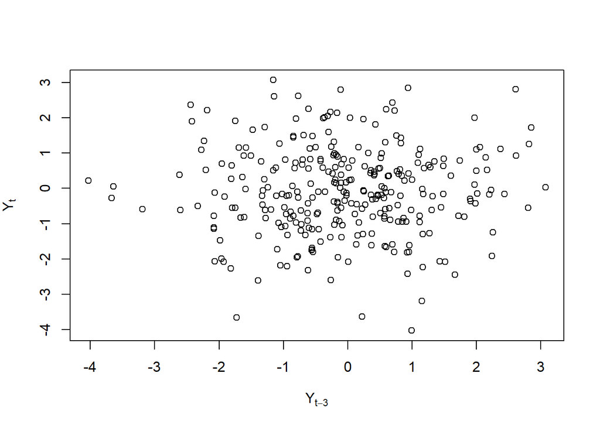

```r
plot(y=yt_ma,x=yt_3_ma, xlab = expression(Y[t-3]), ylab = expression(Y[t]))
```

```r
cor(yt_ma,yt_3_ma)
```

```
## [1] 0.01773598
```

```r
yt_ma2 <- ma2[-c(1,2,3)]
yt_ma2
```

```
##   [1] -0.94650040 -1.27302282 -0.93257038 -0.20948698 -0.84375297 -1.31986306
##   [7] -1.03172899 -0.77220254 -0.06164654 -1.09349057 -0.26429649 -0.09777742
##  [13] -1.72804606 -2.60376052 -1.39132346 -3.66664759 -0.61960280 -2.61273370
##  [19] -0.26645449 -2.32703949  0.38658598 -1.39004774 -0.49767521 -0.80366432
##  [25] -1.34193156  1.16489039 -0.96783248  0.76369215 -1.29136639  0.81456487
##  [31]  0.48236602  1.74372597  0.53083383  0.56713354  0.78510851  0.99243764
##  [37] -0.78850278 -0.94376719 -4.03032049 -1.95219410 -2.20412161  0.22077134
##  [43]  0.69496167  0.52951702 -0.57554525 -1.58292862 -0.17992596  0.13559175
##  [49]  1.15519072 -0.89162673 -1.59054022 -3.18805627 -0.84797971 -0.01836624
##  [55] -0.58586163  1.45007397 -0.19047103  1.12671518 -0.54419029  0.24144397
##  [61]  1.11449173  1.48855336  1.97024328 -0.78458242  0.63827211  0.10884769
##  [67] -0.10113063  0.36160259 -0.72291173 -0.55483175 -0.18132028 -1.01880324
##  [73] -1.69429360  0.13842276 -0.16186610  1.15849591 -0.44877536 -0.42478165
##  [79] -0.02484026 -1.15445539  0.82793828  0.16930391  3.07296855  1.28319888
##  [85]  1.16989388  0.03098812  0.59488650 -0.15762106  0.23751592 -1.66411327
```

[output cut: 35 more lines]

```r
yt_3_ma2 <- ma2[-c(298, 299,300)]
yt_3_ma2
```

```
##   [1]  0.84487319  1.26935901 -0.13233979 -0.94650040 -1.27302282 -0.93257038
##   [7] -0.20948698 -0.84375297 -1.31986306 -1.03172899 -0.77220254 -0.06164654
##  [13] -1.09349057 -0.26429649 -0.09777742 -1.72804606 -2.60376052 -1.39132346
##  [19] -3.66664759 -0.61960280 -2.61273370 -0.26645449 -2.32703949  0.38658598
##  [25] -1.39004774 -0.49767521 -0.80366432 -1.34193156  1.16489039 -0.96783248
##  [31]  0.76369215 -1.29136639  0.81456487  0.48236602  1.74372597  0.53083383
##  [37]  0.56713354  0.78510851  0.99243764 -0.78850278 -0.94376719 -4.03032049
##  [43] -1.95219410 -2.20412161  0.22077134  0.69496167  0.52951702 -0.57554525
##  [49] -1.58292862 -0.17992596  0.13559175  1.15519072 -0.89162673 -1.59054022
##  [55] -3.18805627 -0.84797971 -0.01836624 -0.58586163  1.45007397 -0.19047103
##  [61]  1.12671518 -0.54419029  0.24144397  1.11449173  1.48855336  1.97024328
##  [67] -0.78458242  0.63827211  0.10884769 -0.10113063  0.36160259 -0.72291173
##  [73] -0.55483175 -0.18132028 -1.01880324 -1.69429360  0.13842276 -0.16186610
##  [79]  1.15849591 -0.44877536 -0.42478165 -0.02484026 -1.15445539  0.82793828
##  [85]  0.16930391  3.07296855  1.28319888  1.16989388  0.03098812  0.59488650
```

[output cut: 35 more lines]

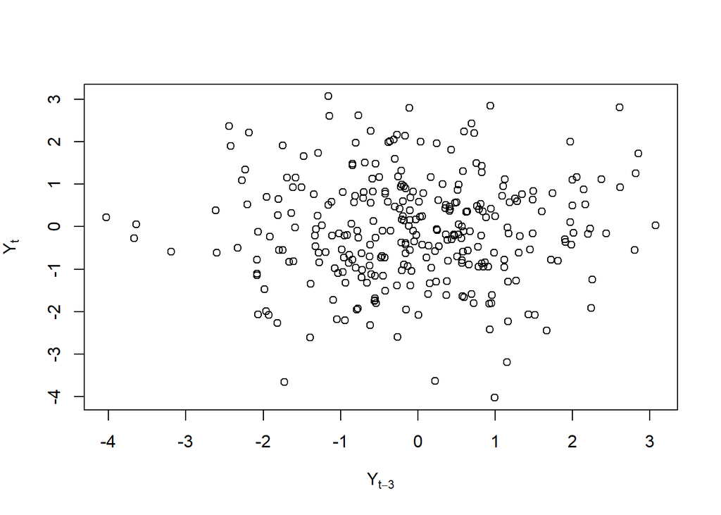

```r
plot(y=yt_ma2,x=yt_3_ma2, xlab = expression(Y[t-3]), ylab = expression(Y[t]))
```

```r
cor(yt_ma2,yt_3_ma2)
```

```
## [1] 0.01963991
```

## Autokorelasi

### Teoretis

```r
t1 <- 0.4
t2 <- 0.6

denom <- 1 + t1^2 + t2^2

rho0 <- 1
rho1 <- (t1 + t1*t2) / denom
rho2 <- t2 / denom
rho3 <- 0
rho4 <- 0

c(rho0, rho1, rho2, rho3, rho4)
```

```
## [1] 1.0000000 0.4210526 0.3947368 0.0000000 0.0000000
```

### Empiris/Data Bangkitan

```r
emp_ma<-acf(ma, lag.max = 10, plot = FALSE)$acf
emp_ma
```

```
## , , 1
##
##              [,1]
##  [1,]  1.00000000
##  [2,]  0.41272634
##  [3,]  0.43637205
##  [4,]  0.01766809
##  [5,]  0.05515280
##  [6,]  0.02700699
##  [7,]  0.03043705
##  [8,]  0.03310948
##  [9,] -0.03676716
## [10,] -0.03996790
## [11,] -0.10087889
```

```r
emp_ma2<-acf(ma2, lag.max = 10, plot = FALSE)$acf
emp_ma2
```

```
## , , 1
##
##              [,1]
##  [1,]  1.00000000
##  [2,]  0.41502289
##  [3,]  0.43833743
##  [4,]  0.01950605
##  [5,]  0.05433503
##  [6,]  0.02355147
##  [7,]  0.02775237
##  [8,]  0.03118028
##  [9,] -0.03725973
## [10,] -0.04286027
## [11,] -0.10801720
```

# Proses AR (2)

## Pembangkitan Model

### Manual

```r
n  <- length(wn)
ar <- numeric(n)

ar[1] <- wn[1]
ar[2] <- wn[2] + 0.5 * ar[1]

for (i in 3:n) {
  ar[i] <- wn[i] + 0.5 * ar[i-1] + 0.2 * ar[i-2]
}
ar
```

```
##   [1] -1.059048109 -0.128300890  1.043852722  0.996966177 -0.417253824
##   [6] -0.806351090 -0.766097688 -0.886830447 -0.501434361 -1.104409568
##  [11] -1.758944441 -1.283706226 -1.028632031 -0.708696535 -1.657515519
##  [16] -0.833233654 -0.242338210 -2.300532628 -3.300876789 -1.453381173
##  [21] -4.055093336 -2.264832991 -2.976588395 -1.826487936 -3.261618346
##  [26] -0.977161812 -1.886696278 -1.949505998 -1.383991355 -1.924633501
##  [31]  0.282009476 -1.314562267 -0.321605670 -1.184406920  0.294752788
##  [36]  0.468765057  1.242984610  0.531256513  0.585163328  1.265959502
##  [41]  1.353036551 -0.620278175 -0.725118103 -3.312707631 -2.211782567
##  [46] -2.112736602 -0.893988878 -0.209892190 -0.380928241 -1.164903805
##  [51] -1.810271052 -0.297912097 -0.020520085  0.385029670 -1.179458866
##  [56] -1.829039129 -2.991219545 -1.183284649 -0.375020733 -1.742854897
##  [61]  0.542198116 -0.072182271  0.303769983 -0.502484146  0.168076074
##  [66]  1.338566883  1.434303261  1.849531044 -0.357665424  0.938262628
##  [71]  1.149145225 -0.087837767  0.436609717 -0.112416501 -0.548876267
```

[output cut: 45 more lines]

### Fungsi arima.sim

```r
set.seed(1048)
ar2 <- arima.sim(list(order=c(2,0,0), ar=c(0.5, 0.2)), n=300)
ar2
```

```
## Time Series:
## Start = 1
## End = 300
## Frequency = 1
##   [1] -0.977161812 -1.886696278 -1.949505998 -1.383991355 -1.924633501
##   [6]  0.282009476 -1.314562267 -0.321605670 -1.184406920  0.294752788
##  [11]  0.468765057  1.242984610  0.531256513  0.585163328  1.265959502
##  [16]  1.353036551 -0.620278175 -0.725118103 -3.312707631 -2.211782567
##  [21] -2.112736602 -0.893988878 -0.209892190 -0.380928241 -1.164903805
##  [26] -1.810271052 -0.297912097 -0.020520085  0.385029670 -1.179458866
##  [31] -1.829039129 -2.991219545 -1.183284649 -0.375020733 -1.742854897
##  [36]  0.542198116 -0.072182271  0.303769983 -0.502484146  0.168076074
##  [41]  1.338566883  1.434303261  1.849531044 -0.357665424  0.938262628
##  [46]  1.149145225 -0.087837767  0.436609717 -0.112416501 -0.548876267
##  [51] -0.058353445 -0.905188431 -1.995204714  0.031900512 -0.110609127
```

[output cut: 49 more lines]

## Karakteristik AR (2)

### Plot Time Series

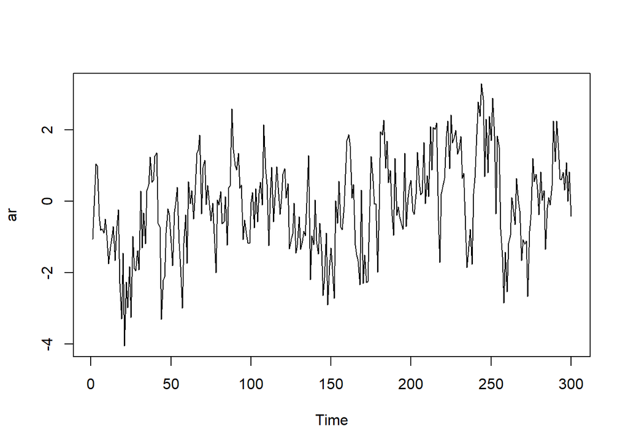

```r
ts.plot(ar)
```

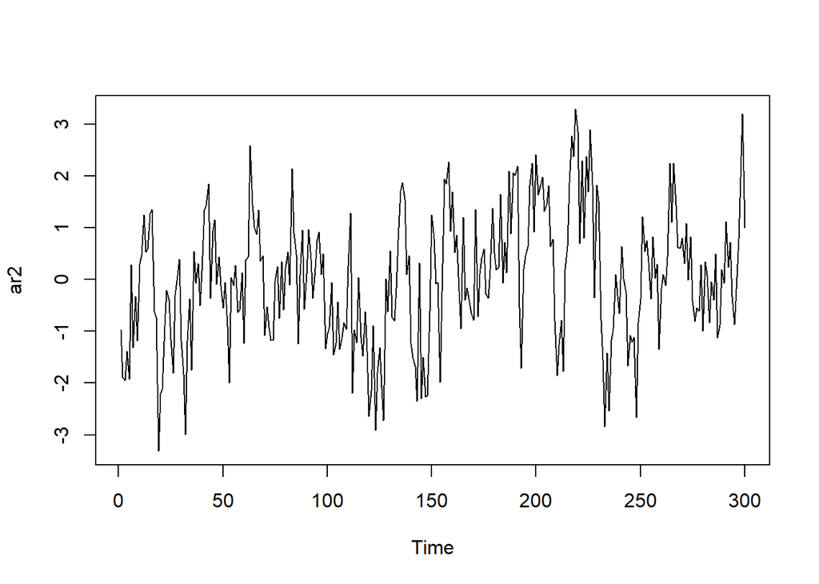

```r
ts.plot(ar2)
```

### Plot ACF

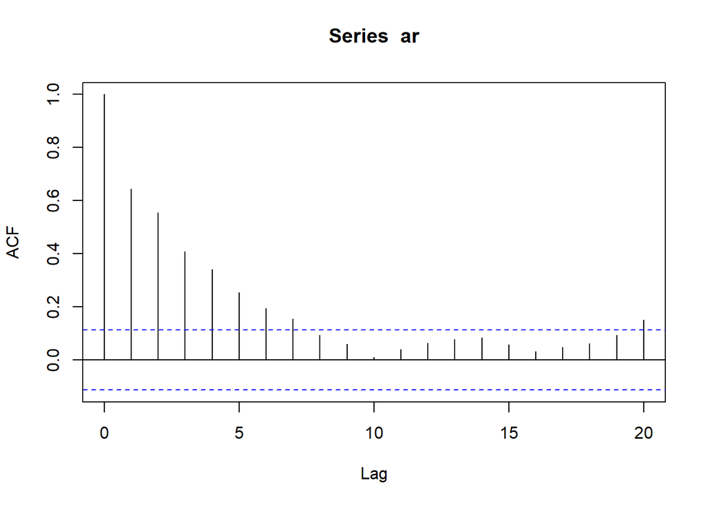

```r
acf(ar,lag.max = 20)
```

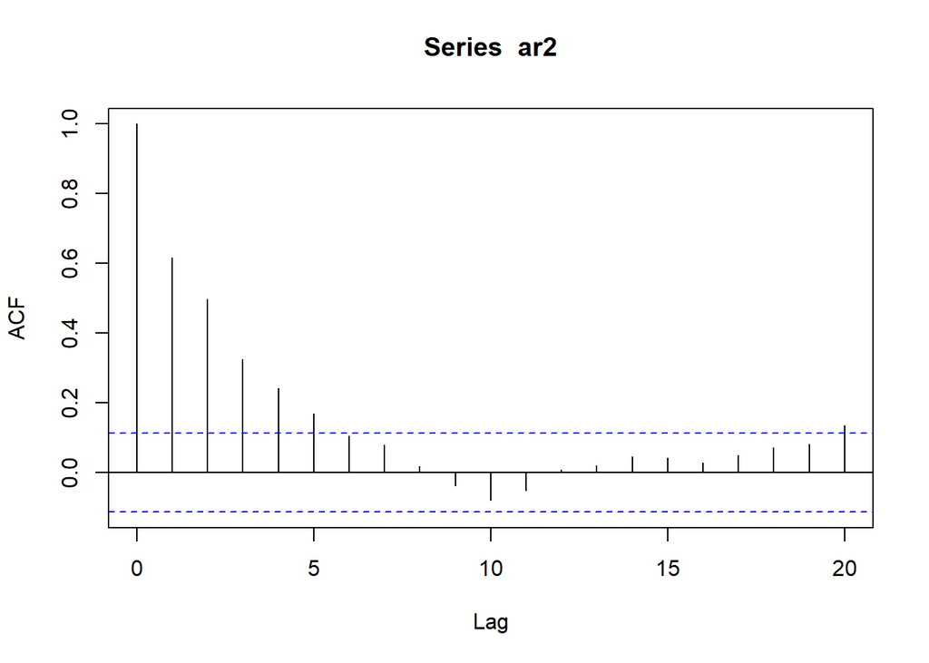

```r
acf(ar2,lag.max = 20)
```

### Plot PACF

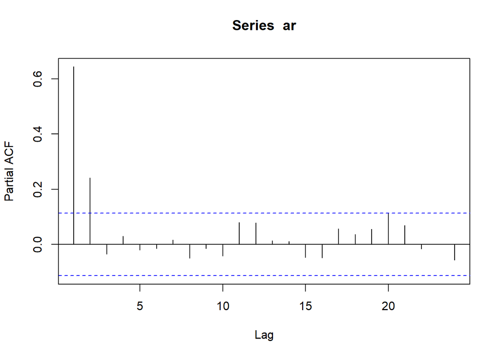

```r
pacf(ar)
```

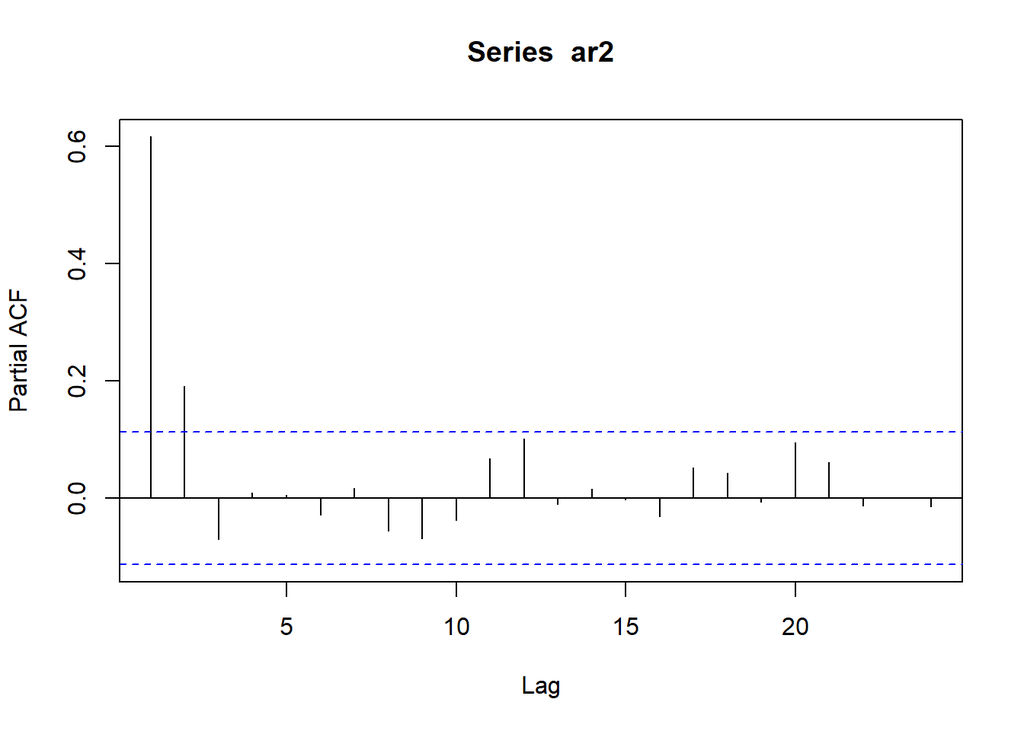

```r
pacf(ar2)
```

### Plot EACF

```r
TSA::eacf(ar)
```

```
## AR/MA
##   0 1 2 3 4 5 6 7 8 9 10 11 12 13
## 0 x x x x x x x o o o o  o  o  o
## 1 x x o o o o o o o o o  o  o  o
## 2 x o o o o o o o o o o  o  o  o
## 3 x o o o o o o o o o o  o  o  o
## 4 x o o o o o o o o o o  o  o  o
## 5 x x x o o o o o o x o  o  o  o
## 6 x o x x o o o o o x o  o  o  o
## 7 x x x o o o o o o x o  o  o  o
```

```r
TSA::eacf(ar2)
```

```
## AR/MA
##   0 1 2 3 4 5 6 7 8 9 10 11 12 13
## 0 x x x x x o o o o o o  o  o  o
## 1 x x o o o o o o o o o  o  o  o
## 2 x o o o o o o o o o o  o  o  o
## 3 o o o o o o o o o o o  o  o  o
## 4 x o o o o o o o o o o  o  o  o
## 5 x x x o o o o o o o o  o  o  o
## 6 x x x o o o o o o o o  o  o  o
## 7 x x x o x o o o o o o  o  o  o
```

## Scatter Plot antar Lag

### $Y_{t}$ dengan $Y_{t-1}$

```r
yt_ar <- ar[-1]
yt_ar
```

```
##   [1] -0.128300890  1.043852722  0.996966177 -0.417253824 -0.806351090
##   [6] -0.766097688 -0.886830447 -0.501434361 -1.104409568 -1.758944441
##  [11] -1.283706226 -1.028632031 -0.708696535 -1.657515519 -0.833233654
##  [16] -0.242338210 -2.300532628 -3.300876789 -1.453381173 -4.055093336
##  [21] -2.264832991 -2.976588395 -1.826487936 -3.261618346 -0.977161812
##  [26] -1.886696278 -1.949505998 -1.383991355 -1.924633501  0.282009476
##  [31] -1.314562267 -0.321605670 -1.184406920  0.294752788  0.468765057
##  [36]  1.242984610  0.531256513  0.585163328  1.265959502  1.353036551
##  [41] -0.620278175 -0.725118103 -3.312707631 -2.211782567 -2.112736602
##  [46] -0.893988878 -0.209892190 -0.380928241 -1.164903805 -1.810271052
##  [51] -0.297912097 -0.020520085  0.385029670 -1.179458866 -1.829039129
##  [56] -2.991219545 -1.183284649 -0.375020733 -1.742854897  0.542198116
##  [61] -0.072182271  0.303769983 -0.502484146  0.168076074  1.338566883
##  [66]  1.434303261  1.849531044 -0.357665424  0.938262628  1.149145225
##  [71] -0.087837767  0.436609717 -0.112416501 -0.548876267 -0.058353445
```

[output cut: 45 more lines]

```r
yt_1_ar <- ar[-300]
yt_1_ar
```

```
##   [1] -1.059048109 -0.128300890  1.043852722  0.996966177 -0.417253824
##   [6] -0.806351090 -0.766097688 -0.886830447 -0.501434361 -1.104409568
##  [11] -1.758944441 -1.283706226 -1.028632031 -0.708696535 -1.657515519
##  [16] -0.833233654 -0.242338210 -2.300532628 -3.300876789 -1.453381173
##  [21] -4.055093336 -2.264832991 -2.976588395 -1.826487936 -3.261618346
##  [26] -0.977161812 -1.886696278 -1.949505998 -1.383991355 -1.924633501
##  [31]  0.282009476 -1.314562267 -0.321605670 -1.184406920  0.294752788
##  [36]  0.468765057  1.242984610  0.531256513  0.585163328  1.265959502
##  [41]  1.353036551 -0.620278175 -0.725118103 -3.312707631 -2.211782567
##  [46] -2.112736602 -0.893988878 -0.209892190 -0.380928241 -1.164903805
##  [51] -1.810271052 -0.297912097 -0.020520085  0.385029670 -1.179458866
##  [56] -1.829039129 -2.991219545 -1.183284649 -0.375020733 -1.742854897
##  [61]  0.542198116 -0.072182271  0.303769983 -0.502484146  0.168076074
##  [66]  1.338566883  1.434303261  1.849531044 -0.357665424  0.938262628
##  [71]  1.149145225 -0.087837767  0.436609717 -0.112416501 -0.548876267
```

[output cut: 45 more lines]

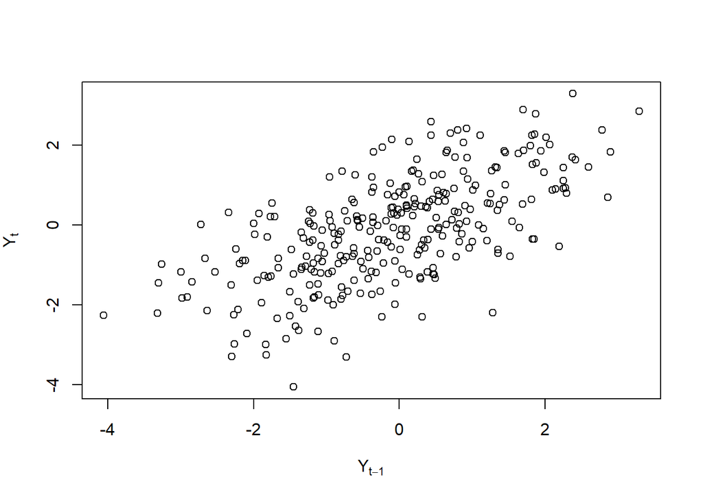

```r
plot(y=yt_ar,x=yt_1_ar, xlab = expression(Y[t-1]), ylab = expression(Y[t]))
```

```r
cor(yt_ar,yt_1_ar)
```

```
## [1] 0.6439703
```

```r
yt_ar2 <- ar2[-1]
yt_ar2
```

```
##   [1] -1.886696278 -1.949505998 -1.383991355 -1.924633501  0.282009476
##   [6] -1.314562267 -0.321605670 -1.184406920  0.294752788  0.468765057
##  [11]  1.242984610  0.531256513  0.585163328  1.265959502  1.353036551
##  [16] -0.620278175 -0.725118103 -3.312707631 -2.211782567 -2.112736602
##  [21] -0.893988878 -0.209892190 -0.380928241 -1.164903805 -1.810271052
##  [26] -0.297912097 -0.020520085  0.385029670 -1.179458866 -1.829039129
##  [31] -2.991219545 -1.183284649 -0.375020733 -1.742854897  0.542198116
##  [36] -0.072182271  0.303769983 -0.502484146  0.168076074  1.338566883
##  [41]  1.434303261  1.849531044 -0.357665424  0.938262628  1.149145225
##  [46] -0.087837767  0.436609717 -0.112416501 -0.548876267 -0.058353445
##  [51] -0.905188431 -1.995204714  0.031900512 -0.110609127  0.274254492
##  [56] -0.626530453 -0.580488997  0.133360542 -1.230192573  0.382477438
##  [61]  0.434608498  2.588464004  1.452841903  1.008533791  0.877042462
##  [66]  1.343579589  0.358912271  0.458991421 -1.074191243 -0.524448706
##  [71] -0.918243660 -1.167037774 -1.174915812 -0.033099965  0.249188471
```

[output cut: 45 more lines]

```r
yt_1_ar2 <- ar2[-300]
yt_1_ar2
```

```
##   [1] -0.977161812 -1.886696278 -1.949505998 -1.383991355 -1.924633501
##   [6]  0.282009476 -1.314562267 -0.321605670 -1.184406920  0.294752788
##  [11]  0.468765057  1.242984610  0.531256513  0.585163328  1.265959502
##  [16]  1.353036551 -0.620278175 -0.725118103 -3.312707631 -2.211782567
##  [21] -2.112736602 -0.893988878 -0.209892190 -0.380928241 -1.164903805
##  [26] -1.810271052 -0.297912097 -0.020520085  0.385029670 -1.179458866
##  [31] -1.829039129 -2.991219545 -1.183284649 -0.375020733 -1.742854897
##  [36]  0.542198116 -0.072182271  0.303769983 -0.502484146  0.168076074
##  [41]  1.338566883  1.434303261  1.849531044 -0.357665424  0.938262628
##  [46]  1.149145225 -0.087837767  0.436609717 -0.112416501 -0.548876267
##  [51] -0.058353445 -0.905188431 -1.995204714  0.031900512 -0.110609127
##  [56]  0.274254492 -0.626530453 -0.580488997  0.133360542 -1.230192573
##  [61]  0.382477438  0.434608498  2.588464004  1.452841903  1.008533791
##  [66]  0.877042462  1.343579589  0.358912271  0.458991421 -1.074191243
##  [71] -0.524448706 -0.918243660 -1.167037774 -1.174915812 -0.033099965
```

[output cut: 45 more lines]

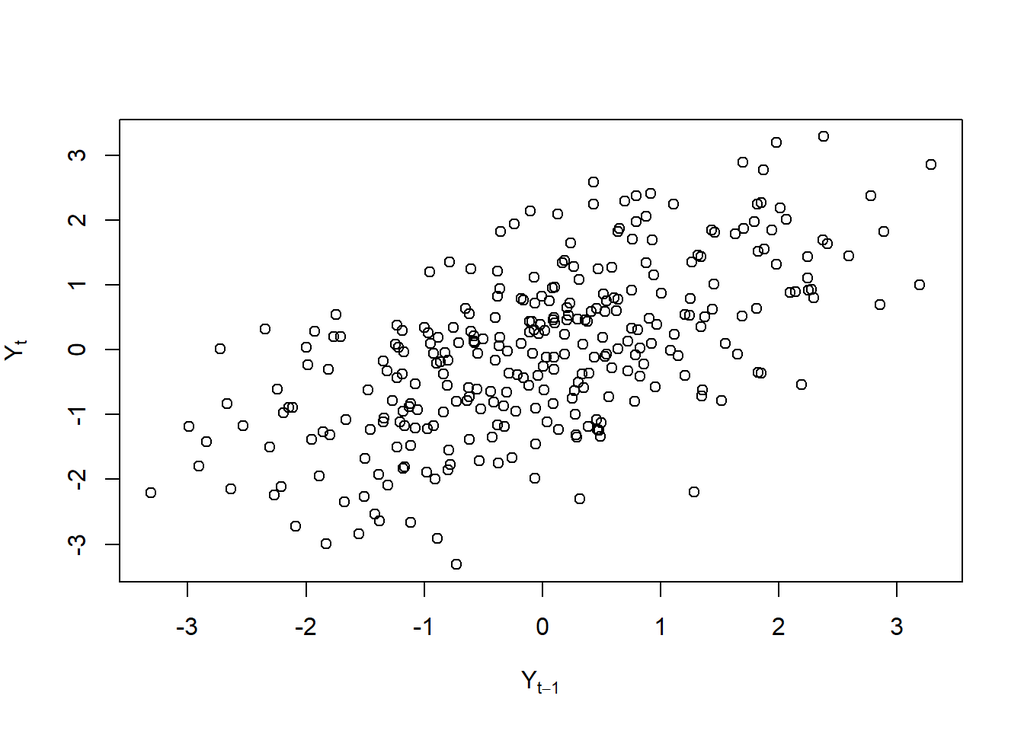

```r
plot(y=yt_ar2,x=yt_1_ar2, xlab = expression(Y[t-1]), ylab = expression(Y[t]))
```

```r
cor(yt_ar2,yt_1_ar2)
```

```
## [1] 0.6180258
```

### $Y_{t}$ dengan $Y_{t-2}$

```r
yt_ar <- ar[-c(1,2)]
yt_ar
```

```
##   [1]  1.043852722  0.996966177 -0.417253824 -0.806351090 -0.766097688
##   [6] -0.886830447 -0.501434361 -1.104409568 -1.758944441 -1.283706226
##  [11] -1.028632031 -0.708696535 -1.657515519 -0.833233654 -0.242338210
##  [16] -2.300532628 -3.300876789 -1.453381173 -4.055093336 -2.264832991
##  [21] -2.976588395 -1.826487936 -3.261618346 -0.977161812 -1.886696278
##  [26] -1.949505998 -1.383991355 -1.924633501  0.282009476 -1.314562267
##  [31] -0.321605670 -1.184406920  0.294752788  0.468765057  1.242984610
##  [36]  0.531256513  0.585163328  1.265959502  1.353036551 -0.620278175
##  [41] -0.725118103 -3.312707631 -2.211782567 -2.112736602 -0.893988878
##  [46] -0.209892190 -0.380928241 -1.164903805 -1.810271052 -0.297912097
##  [51] -0.020520085  0.385029670 -1.179458866 -1.829039129 -2.991219545
##  [56] -1.183284649 -0.375020733 -1.742854897  0.542198116 -0.072182271
##  [61]  0.303769983 -0.502484146  0.168076074  1.338566883  1.434303261
##  [66]  1.849531044 -0.357665424  0.938262628  1.149145225 -0.087837767
##  [71]  0.436609717 -0.112416501 -0.548876267 -0.058353445 -0.905188431
```

[output cut: 45 more lines]

```r
yt_2_ar <- ar[-c(299,300)]
yt_2_ar
```

```
##   [1] -1.059048109 -0.128300890  1.043852722  0.996966177 -0.417253824
##   [6] -0.806351090 -0.766097688 -0.886830447 -0.501434361 -1.104409568
##  [11] -1.758944441 -1.283706226 -1.028632031 -0.708696535 -1.657515519
##  [16] -0.833233654 -0.242338210 -2.300532628 -3.300876789 -1.453381173
##  [21] -4.055093336 -2.264832991 -2.976588395 -1.826487936 -3.261618346
##  [26] -0.977161812 -1.886696278 -1.949505998 -1.383991355 -1.924633501
##  [31]  0.282009476 -1.314562267 -0.321605670 -1.184406920  0.294752788
##  [36]  0.468765057  1.242984610  0.531256513  0.585163328  1.265959502
##  [41]  1.353036551 -0.620278175 -0.725118103 -3.312707631 -2.211782567
##  [46] -2.112736602 -0.893988878 -0.209892190 -0.380928241 -1.164903805
##  [51] -1.810271052 -0.297912097 -0.020520085  0.385029670 -1.179458866
##  [56] -1.829039129 -2.991219545 -1.183284649 -0.375020733 -1.742854897
##  [61]  0.542198116 -0.072182271  0.303769983 -0.502484146  0.168076074
##  [66]  1.338566883  1.434303261  1.849531044 -0.357665424  0.938262628
##  [71]  1.149145225 -0.087837767  0.436609717 -0.112416501 -0.548876267
```

[output cut: 45 more lines]

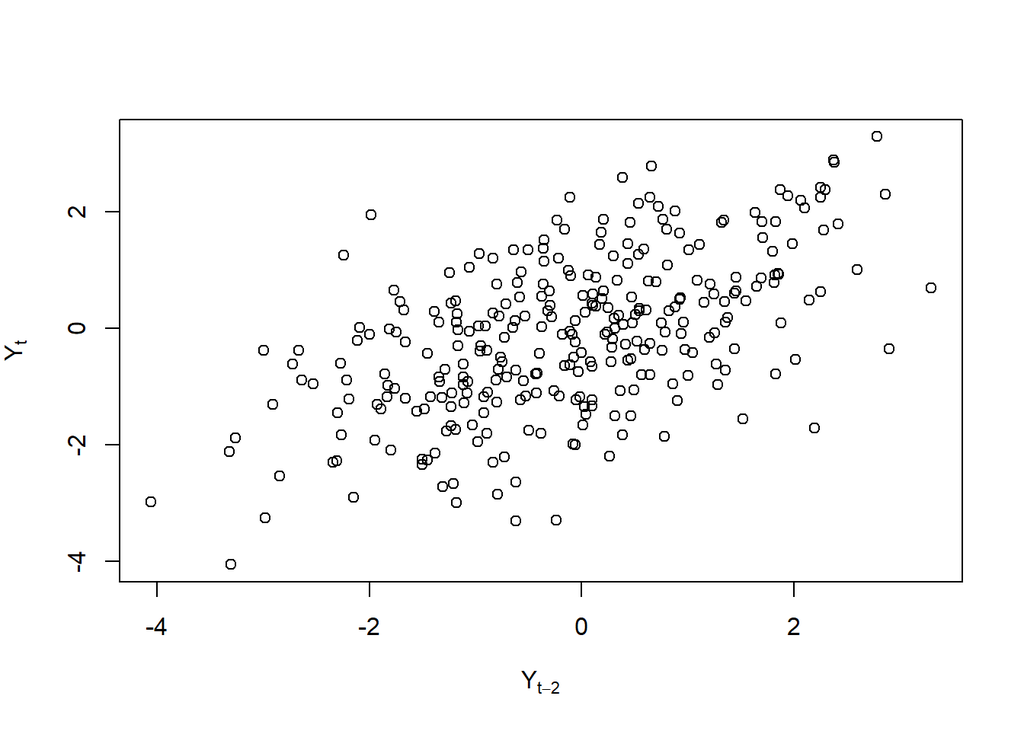

```r
plot(y=yt_ar,x=yt_2_ar, xlab = expression(Y[t-2]), ylab = expression(Y[t]))
```

```r
cor(yt_ar,yt_2_ar)
```

```
## [1] 0.5567067
```

```r
yt_ar2 <- ar2[-c(1,2)]
yt_ar2
```

```
##   [1] -1.949505998 -1.383991355 -1.924633501  0.282009476 -1.314562267
##   [6] -0.321605670 -1.184406920  0.294752788  0.468765057  1.242984610
##  [11]  0.531256513  0.585163328  1.265959502  1.353036551 -0.620278175
##  [16] -0.725118103 -3.312707631 -2.211782567 -2.112736602 -0.893988878
##  [21] -0.209892190 -0.380928241 -1.164903805 -1.810271052 -0.297912097
##  [26] -0.020520085  0.385029670 -1.179458866 -1.829039129 -2.991219545
##  [31] -1.183284649 -0.375020733 -1.742854897  0.542198116 -0.072182271
##  [36]  0.303769983 -0.502484146  0.168076074  1.338566883  1.434303261
##  [41]  1.849531044 -0.357665424  0.938262628  1.149145225 -0.087837767
##  [46]  0.436609717 -0.112416501 -0.548876267 -0.058353445 -0.905188431
##  [51] -1.995204714  0.031900512 -0.110609127  0.274254492 -0.626530453
##  [56] -0.580488997  0.133360542 -1.230192573  0.382477438  0.434608498
##  [61]  2.588464004  1.452841903  1.008533791  0.877042462  1.343579589
##  [66]  0.358912271  0.458991421 -1.074191243 -0.524448706 -0.918243660
##  [71] -1.167037774 -1.174915812 -0.033099965  0.249188471 -0.750849770
```

[output cut: 45 more lines]

```r
yt_2_ar2 <- ar2[-c(299,300)]
yt_2_ar2
```

```
##   [1] -0.977161812 -1.886696278 -1.949505998 -1.383991355 -1.924633501
##   [6]  0.282009476 -1.314562267 -0.321605670 -1.184406920  0.294752788
##  [11]  0.468765057  1.242984610  0.531256513  0.585163328  1.265959502
##  [16]  1.353036551 -0.620278175 -0.725118103 -3.312707631 -2.211782567
##  [21] -2.112736602 -0.893988878 -0.209892190 -0.380928241 -1.164903805
##  [26] -1.810271052 -0.297912097 -0.020520085  0.385029670 -1.179458866
##  [31] -1.829039129 -2.991219545 -1.183284649 -0.375020733 -1.742854897
##  [36]  0.542198116 -0.072182271  0.303769983 -0.502484146  0.168076074
##  [41]  1.338566883  1.434303261  1.849531044 -0.357665424  0.938262628
##  [46]  1.149145225 -0.087837767  0.436609717 -0.112416501 -0.548876267
##  [51] -0.058353445 -0.905188431 -1.995204714  0.031900512 -0.110609127
##  [56]  0.274254492 -0.626530453 -0.580488997  0.133360542 -1.230192573
##  [61]  0.382477438  0.434608498  2.588464004  1.452841903  1.008533791
##  [66]  0.877042462  1.343579589  0.358912271  0.458991421 -1.074191243
##  [71] -0.524448706 -0.918243660 -1.167037774 -1.174915812 -0.033099965
```

[output cut: 45 more lines]

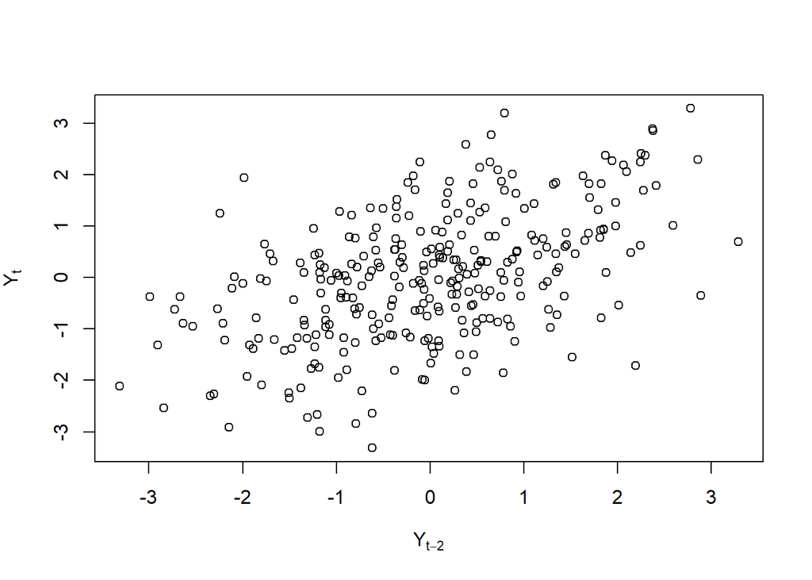

```r
plot(y=yt_ar2,x=yt_2_ar2, xlab = expression(Y[t-2]), ylab = expression(Y[t]))
```

```r
cor(yt_ar2,yt_2_ar2)
```

```
## [1] 0.5069158
```

### $Y_{t}$ dengan $Y_{t-3}$

```r
yt_ar <- ar[-c(1,2,3)]
yt_ar
```

```
##   [1]  0.996966177 -0.417253824 -0.806351090 -0.766097688 -0.886830447
##   [6] -0.501434361 -1.104409568 -1.758944441 -1.283706226 -1.028632031
##  [11] -0.708696535 -1.657515519 -0.833233654 -0.242338210 -2.300532628
##  [16] -3.300876789 -1.453381173 -4.055093336 -2.264832991 -2.976588395
##  [21] -1.826487936 -3.261618346 -0.977161812 -1.886696278 -1.949505998
##  [26] -1.383991355 -1.924633501  0.282009476 -1.314562267 -0.321605670
##  [31] -1.184406920  0.294752788  0.468765057  1.242984610  0.531256513
##  [36]  0.585163328  1.265959502  1.353036551 -0.620278175 -0.725118103
##  [41] -3.312707631 -2.211782567 -2.112736602 -0.893988878 -0.209892190
##  [46] -0.380928241 -1.164903805 -1.810271052 -0.297912097 -0.020520085
##  [51]  0.385029670 -1.179458866 -1.829039129 -2.991219545 -1.183284649
##  [56] -0.375020733 -1.742854897  0.542198116 -0.072182271  0.303769983
##  [61] -0.502484146  0.168076074  1.338566883  1.434303261  1.849531044
##  [66] -0.357665424  0.938262628  1.149145225 -0.087837767  0.436609717
##  [71] -0.112416501 -0.548876267 -0.058353445 -0.905188431 -1.995204714
```

[output cut: 45 more lines]

```r
yt_3_ar <- ar[-c(298, 299,300)]
yt_3_ar
```

```
##   [1] -1.059048109 -0.128300890  1.043852722  0.996966177 -0.417253824
##   [6] -0.806351090 -0.766097688 -0.886830447 -0.501434361 -1.104409568
##  [11] -1.758944441 -1.283706226 -1.028632031 -0.708696535 -1.657515519
##  [16] -0.833233654 -0.242338210 -2.300532628 -3.300876789 -1.453381173
##  [21] -4.055093336 -2.264832991 -2.976588395 -1.826487936 -3.261618346
##  [26] -0.977161812 -1.886696278 -1.949505998 -1.383991355 -1.924633501
##  [31]  0.282009476 -1.314562267 -0.321605670 -1.184406920  0.294752788
##  [36]  0.468765057  1.242984610  0.531256513  0.585163328  1.265959502
##  [41]  1.353036551 -0.620278175 -0.725118103 -3.312707631 -2.211782567
##  [46] -2.112736602 -0.893988878 -0.209892190 -0.380928241 -1.164903805
##  [51] -1.810271052 -0.297912097 -0.020520085  0.385029670 -1.179458866
##  [56] -1.829039129 -2.991219545 -1.183284649 -0.375020733 -1.742854897
##  [61]  0.542198116 -0.072182271  0.303769983 -0.502484146  0.168076074
##  [66]  1.338566883  1.434303261  1.849531044 -0.357665424  0.938262628
##  [71]  1.149145225 -0.087837767  0.436609717 -0.112416501 -0.548876267
```

[output cut: 45 more lines]

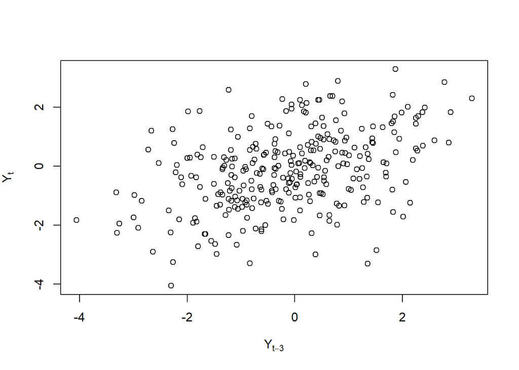

```r
plot(y=yt_ar,x=yt_3_ar, xlab = expression(Y[t-3]), ylab = expression(Y[t]))
```

```r
cor(yt_ar,yt_3_ar)
```

```
## [1] 0.4090285
```

```r
yt_ar2 <- ar2[-c(1,2,3)]
yt_ar2
```

```
##   [1] -1.383991355 -1.924633501  0.282009476 -1.314562267 -0.321605670
##   [6] -1.184406920  0.294752788  0.468765057  1.242984610  0.531256513
##  [11]  0.585163328  1.265959502  1.353036551 -0.620278175 -0.725118103
##  [16] -3.312707631 -2.211782567 -2.112736602 -0.893988878 -0.209892190
##  [21] -0.380928241 -1.164903805 -1.810271052 -0.297912097 -0.020520085
##  [26]  0.385029670 -1.179458866 -1.829039129 -2.991219545 -1.183284649
##  [31] -0.375020733 -1.742854897  0.542198116 -0.072182271  0.303769983
##  [36] -0.502484146  0.168076074  1.338566883  1.434303261  1.849531044
##  [41] -0.357665424  0.938262628  1.149145225 -0.087837767  0.436609717
##  [46] -0.112416501 -0.548876267 -0.058353445 -0.905188431 -1.995204714
##  [51]  0.031900512 -0.110609127  0.274254492 -0.626530453 -0.580488997
##  [56]  0.133360542 -1.230192573  0.382477438  0.434608498  2.588464004
##  [61]  1.452841903  1.008533791  0.877042462  1.343579589  0.358912271
##  [66]  0.458991421 -1.074191243 -0.524448706 -0.918243660 -1.167037774
##  [71] -1.174915812 -0.033099965  0.249188471 -0.750849770  0.345451009
```

[output cut: 45 more lines]

```r
yt_3_ar2 <- ar2[-c(298, 299,300)]
yt_3_ar2
```

```
##   [1] -0.977161812 -1.886696278 -1.949505998 -1.383991355 -1.924633501
##   [6]  0.282009476 -1.314562267 -0.321605670 -1.184406920  0.294752788
##  [11]  0.468765057  1.242984610  0.531256513  0.585163328  1.265959502
##  [16]  1.353036551 -0.620278175 -0.725118103 -3.312707631 -2.211782567
##  [21] -2.112736602 -0.893988878 -0.209892190 -0.380928241 -1.164903805
##  [26] -1.810271052 -0.297912097 -0.020520085  0.385029670 -1.179458866
##  [31] -1.829039129 -2.991219545 -1.183284649 -0.375020733 -1.742854897
##  [36]  0.542198116 -0.072182271  0.303769983 -0.502484146  0.168076074
##  [41]  1.338566883  1.434303261  1.849531044 -0.357665424  0.938262628
##  [46]  1.149145225 -0.087837767  0.436609717 -0.112416501 -0.548876267
##  [51] -0.058353445 -0.905188431 -1.995204714  0.031900512 -0.110609127
##  [56]  0.274254492 -0.626530453 -0.580488997  0.133360542 -1.230192573
##  [61]  0.382477438  0.434608498  2.588464004  1.452841903  1.008533791
##  [66]  0.877042462  1.343579589  0.358912271  0.458991421 -1.074191243
##  [71] -0.524448706 -0.918243660 -1.167037774 -1.174915812 -0.033099965
```

[output cut: 45 more lines]

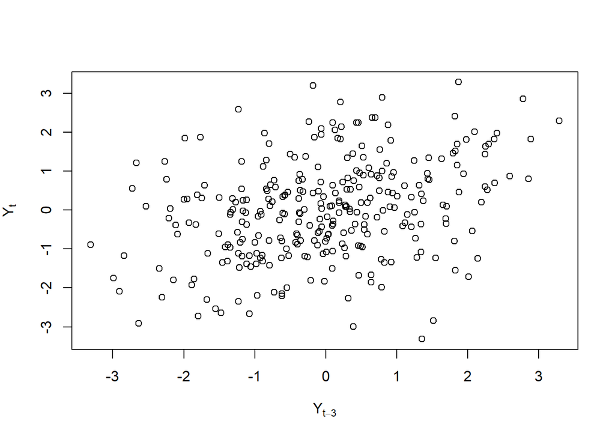

```r
plot(y=yt_ar2,x=yt_3_ar2, xlab = expression(Y[t-3]), ylab = expression(Y[t]))
```

```r
cor(yt_ar2,yt_3_ar2)
```

```
## [1] 0.3333544
```

## Autokorelasi

### Teoretis

```r
phi1 <- 0.5
phi2 <- 0.2

rho0 <- 1
rho1 <- phi1 / (1 - phi2)

rho <- numeric(21)
rho[1] <- 1
rho[2] <- rho1

for (k in 3:21) {
  rho[k] <- phi1 * rho[k-1] + phi2 * rho[k-2]
}
rho
```

```
##  [1] 1.000000000 0.625000000 0.512500000 0.381250000 0.293125000 0.222812500
##  [7] 0.170031250 0.129578125 0.098795312 0.075313281 0.057415703 0.043770508
## [13] 0.033368395 0.025438299 0.019392828 0.014784074 0.011270603 0.008592116
## [19] 0.006550179 0.004993513 0.003806792
```

### Empiris/Data Bangkitan

```r
emp_ar<-acf(ar, lag.max = 10, plot = FALSE)$acf
emp_ar
```

```
## , , 1
##
##              [,1]
##  [1,] 1.000000000
##  [2,] 0.643386579
##  [3,] 0.555721075
##  [4,] 0.407772318
##  [5,] 0.340744859
##  [6,] 0.252917334
##  [7,] 0.194286164
##  [8,] 0.154969661
##  [9,] 0.093054291
## [10,] 0.060286646
## [11,] 0.009656064
```

```r
emp_ar2<-acf(ar2, lag.max = 10, plot = FALSE)$acf
emp_ar2
```

```
## , , 1
##
##              [,1]
##  [1,]  1.00000000
##  [2,]  0.61674699
##  [3,]  0.49839863
##  [4,]  0.32485841
##  [5,]  0.24103843
##  [6,]  0.16774419
##  [7,]  0.10494465
##  [8,]  0.07890165
##  [9,]  0.01784533
## [10,] -0.03672453
## [11,] -0.07980460
```

# Proses ARMA (2,2)

## Pembangkitan Model

### Manual

```r
arma.sim <- function(n, macoef, arcoef){
  manum <- length(macoef)
  arnum <- length(arcoef)
  stopifnot(manum < n & arnum < n)

  wn <- rnorm(n, sd = 0.5)
  init <- max(manum, arnum)

  arma <- wn[1:init]
  for(i in {init+1}:n){
   mastart <- i - manum
   maend <- i-1
   arstart <- i - arnum
   arend <- i-1
   arma[i] <- sum(arcoef * arma[arstart:arend]) + sum(macoef * wn[mastart:maend])  + wn[i]
   }
  return(arma)
}

set.seed(1048)
arma <- arma.sim(n = 300,
                   macoef = c(0.4, 0.6),
                   arcoef = c(0.5, 0.2))
arma
```

```
##   [1] -0.529524054  0.200611582  0.343824011  0.895609060  0.202952645
##   [6] -0.147375886 -0.531771259 -0.594562784 -0.495845677 -0.774555833
##  [11] -1.139918207 -1.174138699 -1.098578043 -0.822772023 -1.250853637
##  [16] -0.909685141 -0.732782132 -1.428570194 -2.205835214 -1.860056475
##  [21] -3.032322040 -2.178833158 -2.986132773 -1.928524691 -2.927498463
##  [26] -1.543252002 -2.190223338 -1.634981938 -1.830433597 -1.776660829
##  [31] -0.769187522 -1.289698047 -0.519863778 -1.259513586 -0.208548691
##  [36] -0.259086619  0.676470583  0.310305872  0.570499205  0.687299729
##  [41]  0.998547206  0.122697677 -0.163371703 -1.900045542 -1.651842674
##  [46] -2.140883330 -1.137102199 -0.855477298 -0.469396686 -0.885074006
##  [51] -1.286705143 -0.811758236 -0.538724575  0.028999923 -0.712937471
##  [56] -1.105631827 -2.166467830 -1.462548593 -1.133032640 -1.237138385
##  [61] -0.302262322 -0.493525438  0.165187337 -0.463207215  0.023538795
##  [66]  0.430199698  0.941732172  1.326205818  0.357142182  0.810271639
##  [71]  0.626697337  0.480345759  0.430058125  0.074804887 -0.103811171
```

[output cut: 45 more lines]

### Fungsi arima.sim

```r
set.seed(1048)
arma2 <- arima.sim(list(order=c(2,0,2), ar=c(0.5, 0.2), ma=c(0.4, 0.6)), n=300)
arma2
```

```
## Time Series:
## Start = 1
## End = 300
## Frequency = 1
##   [1] -3.289948889 -3.295405413 -3.647624046 -1.318002718 -2.356358648
##   [6] -0.678087722 -2.101681978 -0.371893663 -0.123917207  1.607388636
##  [11]  1.309744710  1.543483625  1.818799268  2.210533997  0.680524076
##  [16] -0.161398348 -3.974914844 -3.971931195 -4.985070178 -3.066149987
##  [21] -1.835127361 -1.001276659 -1.443209054 -2.504788481 -1.720962009
##  [26] -1.225846952  0.198074838 -1.037758699 -2.069804606 -4.430510313
##  [31] -3.477195789 -2.643066201 -2.602833890 -0.379956214 -0.901015911
##  [36]  0.600215984 -0.424285485  0.149344429  1.104306843  2.070575672
##  [41]  3.226392489  1.242728958  1.904915090  1.309851026  0.934777903
##  [46]  1.090961748  0.009524728 -0.331877036 -0.345353851 -1.257855568
##  [51] -2.392292153 -1.309294432 -1.294971751  0.249151148 -0.583194132
```

[output cut: 49 more lines]

## Karakteristik ARMA (2,2)

### Plot Time Series

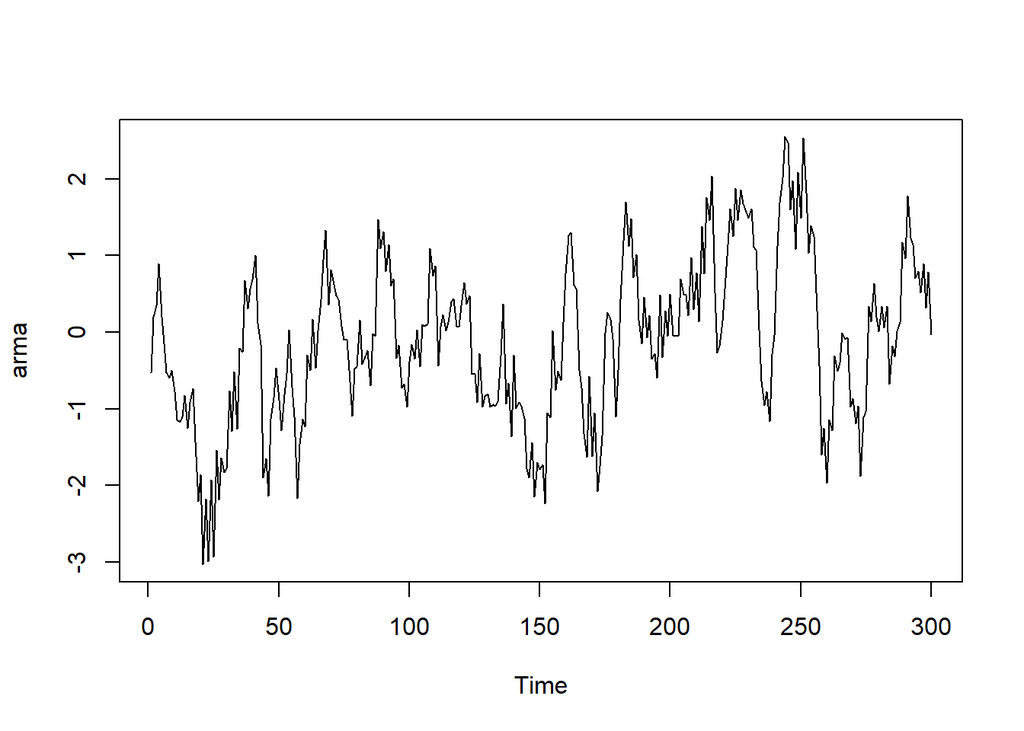

```r
ts.plot(arma)
```

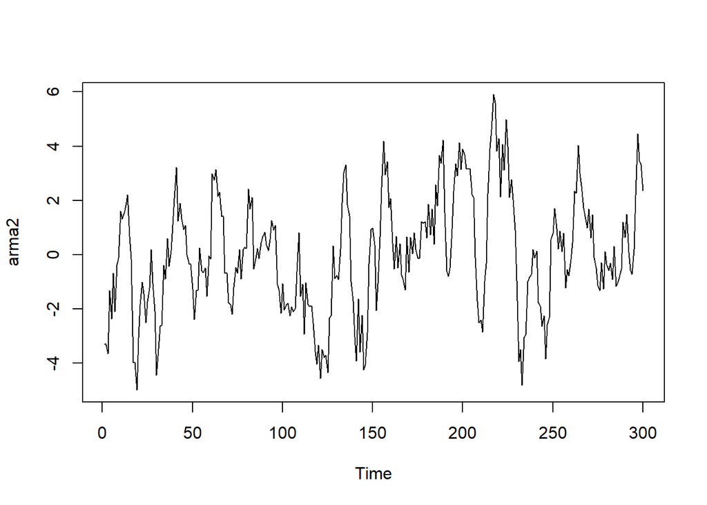

```r
ts.plot(arma2)
```

### Plot ACF

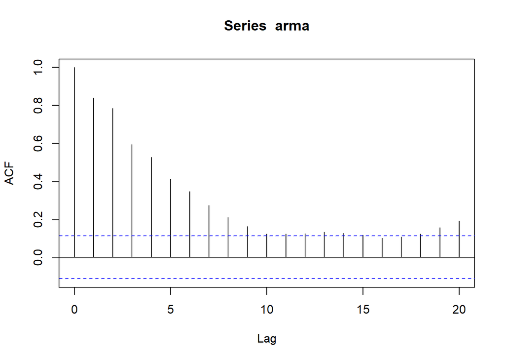

```r
acf(arma,lag.max = 20)
```

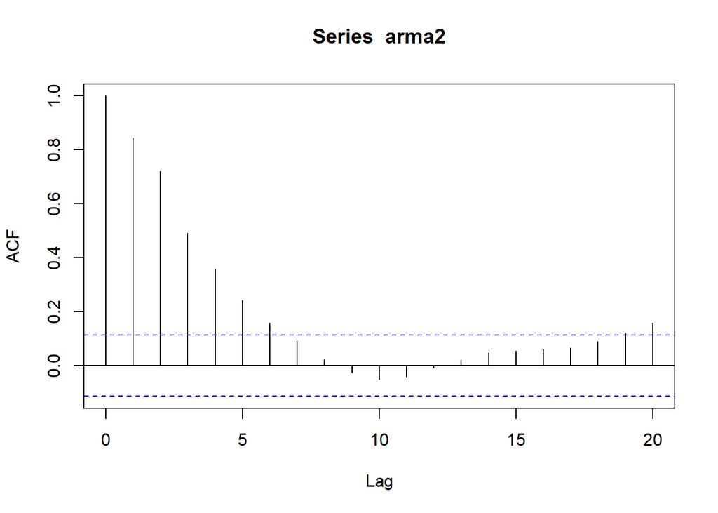

```r
acf(arma2,lag.max = 20)
```

### Plot PACF

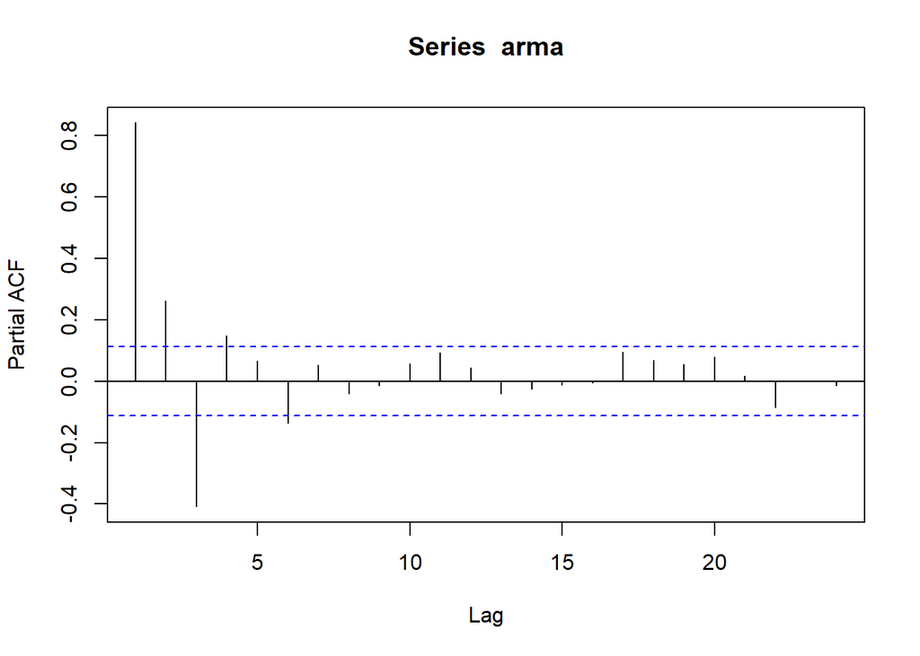

```r
pacf(arma)
```

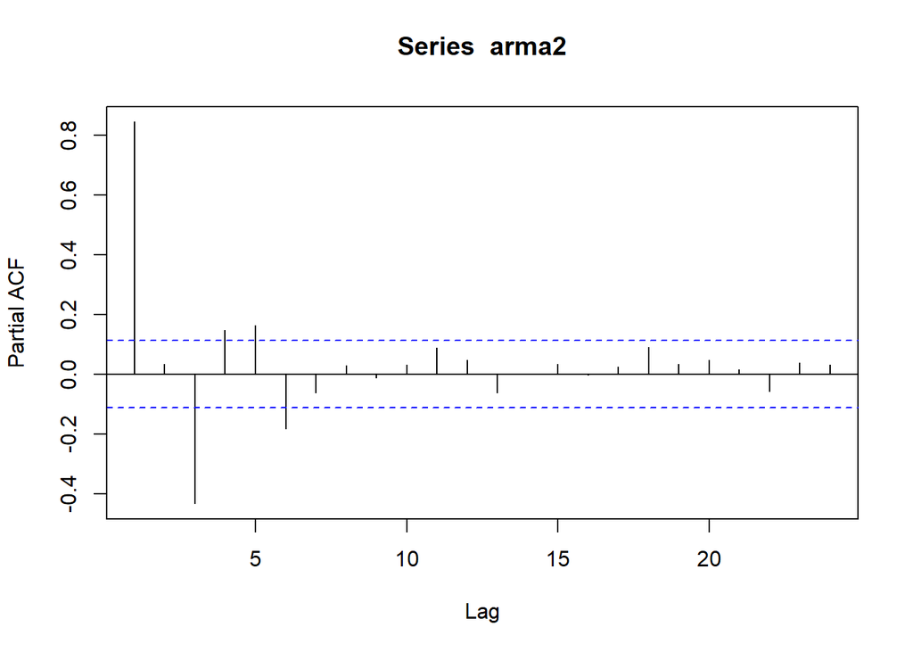

```r
pacf(arma2)
```

### Plot EACF

```r
TSA::eacf(arma)
```

```
## AR/MA
##   0 1 2 3 4 5 6 7 8 9 10 11 12 13
## 0 x x x x x x x x x x x  x  x  x
## 1 x x x x o o o o o x o  o  o  o
## 2 x x o o o o o o o o o  o  o  o
## 3 x x x o o o o o o o o  o  o  o
## 4 x x x x o o o o o x o  o  o  o
## 5 x x x x o o o o o x o  o  o  o
## 6 x x x x o o o o o x o  o  o  o
## 7 x x x x o o o o o x o  o  o  o
```

```r
TSA::eacf(arma2)
```

```
## AR/MA
##   0 1 2 3 4 5 6 7 8 9 10 11 12 13
## 0 x x x x x x o o o o o  o  o  o
## 1 o x o o o o o o o o o  o  o  o
## 2 o x x o o o o o o o o  o  o  o
## 3 x x x o o o o o o o o  o  o  o
## 4 x x x x o o x o o o o  o  o  o
## 5 x x x x o x o o o o o  o  o  o
## 6 x x x x o o o o o o o  o  o  o
## 7 x o o x x o o x o o o  o  o  o
```

### Identifikasi Stasioneritas

Berdasarkan plot time series, model arma atau autoregressive moving average secara manual tampak stasioner dalam rata-rata, tapi tidak stasioner dalam ragam. Hal ini juga terlihat pada plot time series model arma2 atau autoregressive moving average yang dibangkitkan dengan arima.sim, model tampak stasioner dalam rata-rata, tapi tidak stasioner dalam ragam.